# Exercices Part 3

Thomas Levy

12 décembre 2017

## Ex 7.12:

Generation d’une chaine de N(0,1) avec une random walk U[-delta,delta] en faisant varier delta.

### Convergence Rate

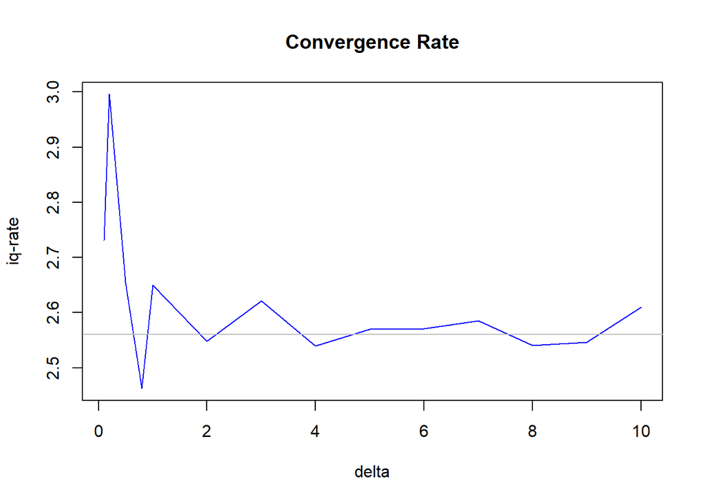

```r
nElements=20000
iqRange = function(delta){
  X=rep(0,nElements)
  nAccept=1
  for (t in 2:nElements){
    y=runif(1,min=-delta,max=+delta)+X[t-1]
    prob=min(exp((X[t-1]^2 - y^2)/2),1)
    if (runif(1)<prob){
      X[t]=y
      nAccept=nAccept+1
    }
    else
    {
      X[t]=X[t-1]
    }
  }
  return (quantile(X,0.9)-quantile(X,0.1))
}

dvalues= c(0.1,0.2,0.5,0.8,1,2,3,4,5,6,7,8,9,10)
iqRanges = lapply(dvalues,iqRange)
plot(x=dvalues,y=iqRanges,type="l",xlab="delta",ylab="iq-rate",lwd=1,col="blue",main="Convergence Rate")
abline(a=2.56,b=0,col="gray")
```

On constate que l’inter-quantile à 90% converge assez rapidement vers sa valeur théorique pour une lois normale (soit 2.56) tracée en gris.

### Acceptance Rate

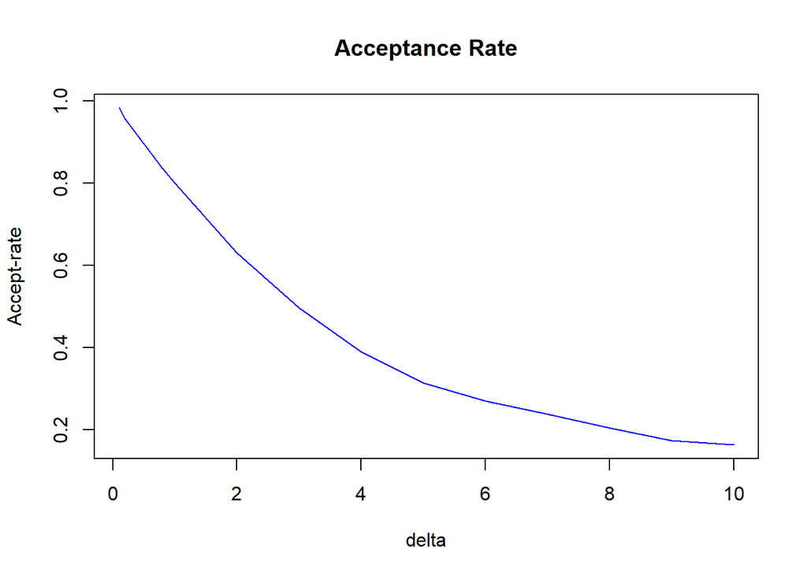

```r
acceptRate = function(delta){
  X=rep(0,nElements)
  nAccept=1
  for (t in 2:nElements){
    y=runif(1,min=-delta,max=+delta)+X[t-1]
    prob=min(exp((X[t-1]^2 - y^2)/2),1)
    if (runif(1)<prob){
      X[t]=y
      nAccept=nAccept+1
    }
    else
    {
      X[t]=X[t-1]
    }
  }
  return (nAccept/nElements)
}

acceptrates = lapply(dvalues,acceptRate)

plot(x=dvalues,y=acceptrates,type="l",xlab="delta",ylab="Accept-rate",lwd=1,col="blue",main="Acceptance Rate")
```

Le taux d’acceptation décroit avec delta. Ce qui est logique.

### Minimisation de la variance de la moyenne empirique

Pour chaque valeur de delta, on va generer la chaine 100 fois. Chaque fois, on calculera la moyenne empirique afin de pouvoir determiner la variance de cette moyenne empirique.

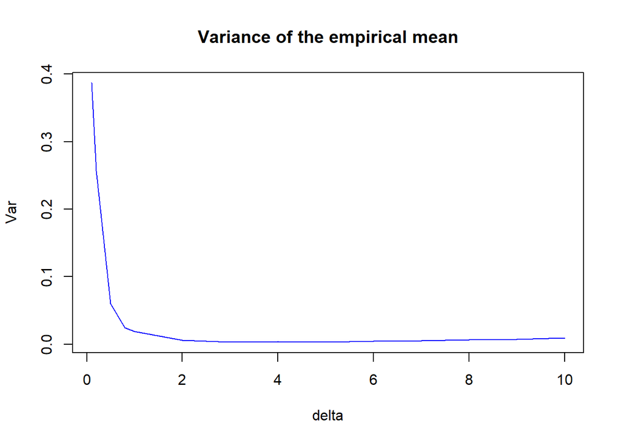

```r
nIterations= 100
nElements=1000
empVariance = function(delta){
  empMean=rep(0,nIterations)
  for (i in 1:nIterations){
    X=rep(0,nElements)
    nAccept=1
    for (t in 2:nElements){
      y=runif(1,min=-delta,max=+delta)+X[t-1]
      prob=min(exp((X[t-1]^2 - y^2)/2),1)
      if (runif(1)<prob){
        X[t]=y
        nAccept=nAccept+1
      }
      else
      {
        X[t]=X[t-1]
      }
    }
    empMean[i]=mean(X)
  }
  return (var(empMean))
}

dvalues= c(0.1,0.2,0.5,0.8,1,2,3,4,5,6,7,8,9,10)
empVariances = lapply(dvalues,empVariance)
plot(x=dvalues,y=empVariances,type="l",xlab="delta",ylab="Var",lwd=1,col="blue",main="Variance of the empirical mean")
```

Le minimum de variance semble se trouver entre 2 et 10. Mais, cette courbe ne nous permet pas de conclure. Aussi, on va tracer une autre courbe plus re-centrée.

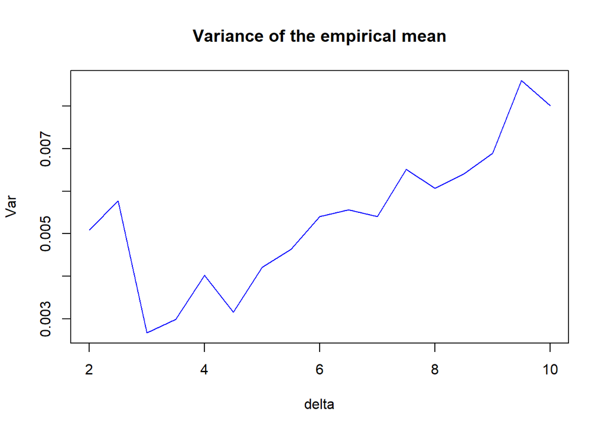

```r
dvalues= seq(2,10,0.5)
empVariances = lapply(dvalues,empVariance)
plot(x=dvalues,y=empVariances,type="l",xlab="delta",ylab="Var",lwd=1,col="blue",main="Variance of the empirical mean")
```

## Ex 7.6:

D’après 7.5, la distribution stationaire f(x) est: $f(x) =\propto \frac{g(x)}{1-\rho(x)}$

Donc pour une loi Be(alpha+1,1): $f(x)\propto x^{\alpha-1}$

Donc, par exemple pour alpha=1, f(x) est une distribution uniforme. Ce qu’on va valider avec l’implementation de l’algo “Repeat or Simulate” plus bas:

### Implementation de l’algo Repeat or Simulate

On vérifié la densité de X pour alpha=0.5, 1 et 1.5.

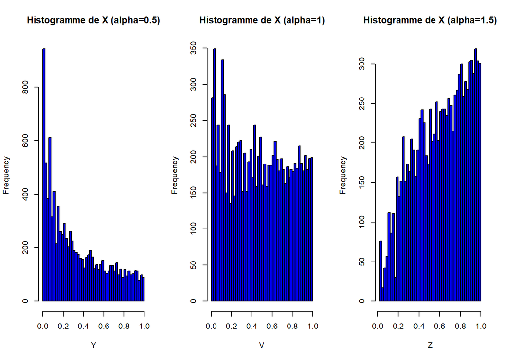

```r
nElements=10000

repeatAlgo=function(alpha){
  X=rep(0,nElements)
  X[1]=rbeta(1, alpha + 1, 1)
  for (i in 2:nElements){
    if (runif(1) < (1-X[i-1])){ #Repeat
      X[i]= X[i-1]
    }
    else{ #Simulate
      X[i]= rbeta(1, alpha + 1, 1)
      #print(X[i])
    }
  }
  return(X)
}

#alpha=0.5
Y=repeatAlgo(0.5)
V=repeatAlgo(1)
Z=repeatAlgo(1.5)

op = par(mfcol=c(1,3),bg="white")
hist(Y,col= "blue",breaks = 50,main="Histogramme de X (alpha=0.5)")
hist(V,col= "blue",breaks = 50,main="Histogramme de X (alpha=1)")
hist(Z,col= "blue",breaks = 50,main="Histogramme de X (alpha=1.5)")
```

Ces densités s’approchent bien de la distribution stationaire de f(x) determinée précédemment (avec différentes valeurs d’alpha)

### Determination de l’acceptance rate

On suppose ici que l’accept correspond au cas ou l’algo fait du repeat. On trace la courbe de l’acceptance-rate pour differentes valeurs de alpha (entre 0.2 et 2)

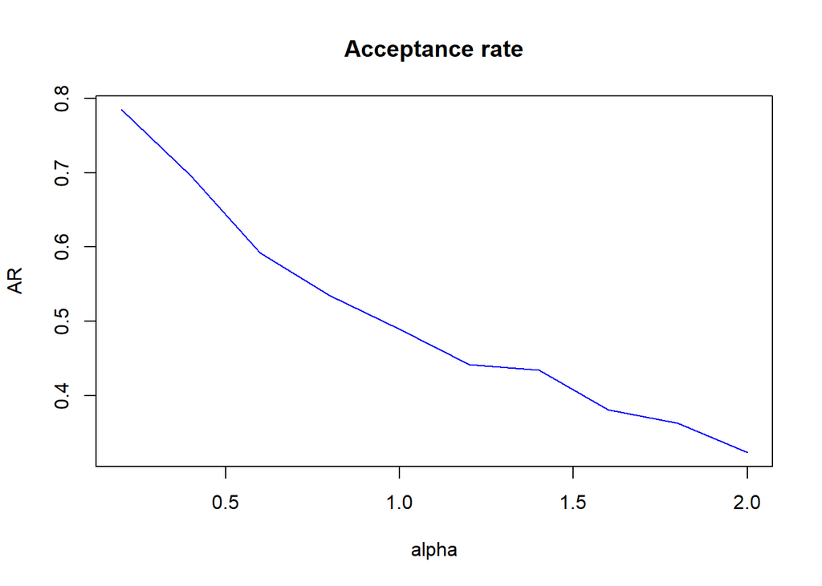

```r
repeatAlgoRate=function(alpha){
  X=rep(0,nElements)
  X[1]=rbeta(1, alpha + 1, 1)
  nAccept=1
  for (i in 2:nElements){
    if (runif(1) < (1-X[i-1])){ #Repeat
      X[i]= X[i-1]
      nAccept=nAccept+1
    }
    else{ #Simulate
      X[i]= rbeta(1, alpha + 1, 1)
      #print(X[i])
    }
  }
  return(nAccept/nElements)
}

avalues=seq(0.2,2,0.2)
repeatAlgoRates = lapply(avalues,repeatAlgoRate)

op = par(mfcol=c(1,1),bg="white")
plot(x=avalues,y=repeatAlgoRates,type="l",xlab="alpha",ylab="AR",lwd=1,col="blue",main="Acceptance rate")
```

## Ex 8.4:

D’après l’exercice 8.3, on sait qu’on peut simuler une chaine X(t) suivant f(x) avec l’algo A.31 même si la fonction f(x) est non-normalisée. Donc pour évaluer la performance du slice sampler, on va comparer la densité de la chaine simulée (avec f(x) non-normalisée) avec la densité théorique f(x) (non normalisée). A une constante multiplicative pres, les courbes de densité simulée et théorique avec f(x) devraient etre les mêmes.

### Pour d=0.4

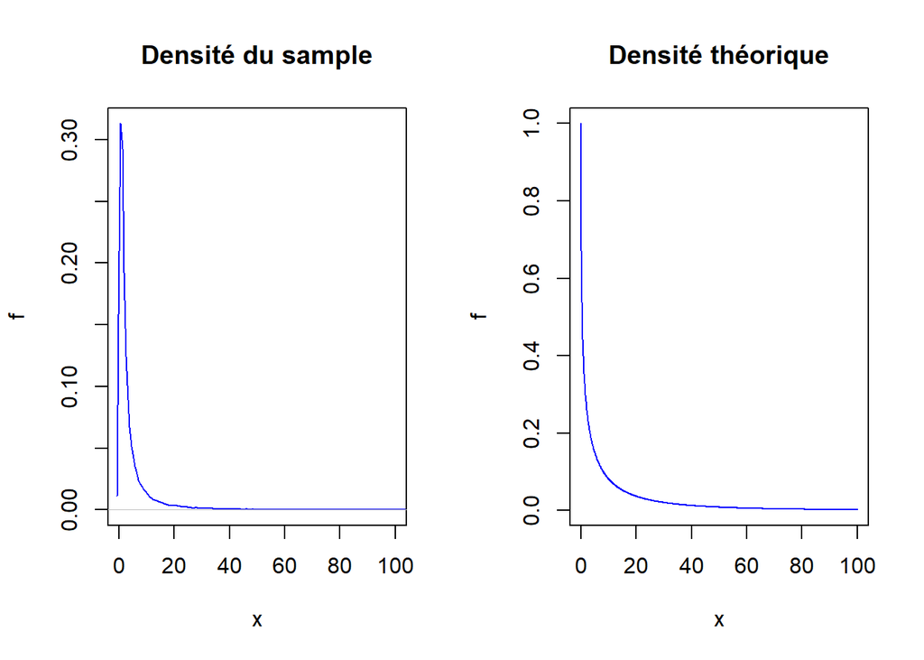

```r
slice = function(d,n){
  burnin=1000
  samples = rep(0, n)
  x=1 #Initialize at 1
  for (t in 1:(burnin + n)){
    u = runif(1,0, exp(-x^d))
    X = runif(1,0, (-log(u))^(1/d))
    if (t > burnin){
      samples[t - burnin]= X
    }
  }
  return(samples)
}

d=0.4
nElements=50000
Delta = 0.1
x = seq(from=0, to=100, by = Delta)
op = par(mfcol=c(1,2),bg="white")
slicesamples= slice(d,nElements)
plot(density(slicesamples),type="l",xlab="x",ylab="f",xlim=c(0,100),lwd=1,col="blue",main="Densité du sample")
plot(x=x,y=exp(-x^d),type="l",xlab="x",ylab="f",xlim=c(0,100),lwd=1,col="blue",main="Densité théorique")
```

Dans ce cas, la densité théorique de f(x) et la densité du sample sont assez proche donc la simulation semble de bonne qualité.

### Pour d=0.25

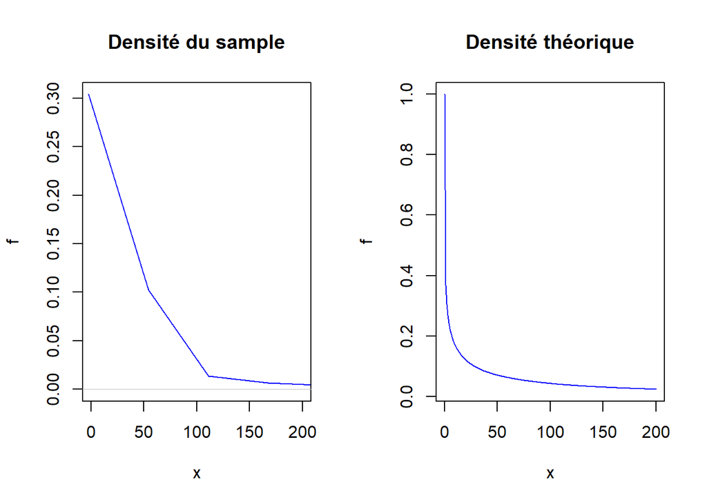

```r
d=0.25
nElements=100000
Delta = 1
x = seq(from=0, to=200, by = Delta)
op = par(mfcol=c(1,2),bg="white")
slicesamples= slice(d,nElements)
plot(density(slicesamples),type="l",xlab="x",ylab="f",xlim=c(0,200),lwd=1,col="blue",main="Densité du sample")
plot(x=x,y=exp(-x^d),type="l",xlab="x",ylab="f",xlim=c(0,200),lwd=1,col="blue",main="Densité théorique")
```

Dans ce cas, la densité théorique de f(x) et la densité du sample s’eccartent donc la simulation n’est plus de bonne qualité.

### Pour d=0.1

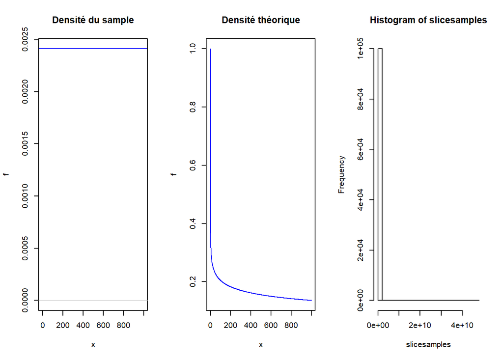

```r
d=0.1
Delta = 1
x = seq(from=0, to=1000, by = Delta)
op = par(mfcol=c(1,3),bg="white")
slicesamples= slice(d,nElements)
plot(density(slicesamples),type="l",xlab="x",ylab="f",xlim=c(0,1000),lwd=1,col="blue",main="Densité du sample")
plot(x=x,y=exp(-x^d),type="l",xlab="x",ylab="f",xlim=c(0,1000),lwd=1,col="blue",main="Densité théorique")
hist(slicesamples)
```

Dans ce cas, la densité du sample n’a plus rien à voir avec la densité théorique. L’histogramme confirme que les valeurs simulées s’eccartent énormement des valeurs théoriques. La performance est très mauvaise dans ce cas.

## Ex 10.2:

On va utiliser l’algorithm Gibbs sampler pour simuler le modele Isling. On dira que les elements S du modele peuvent être representés à 2 dimensions avec un indice matriciel (n par n) ou un indice à 1 dimension (nxn). Si on considere S sous forme à une dimension, on peut appliquer Gibbs sampler sur ses loi conditionnelles pour chaque indice de 1 à nxn.

### Implementation

On génère d’abbord un modele initial (taille nxn) avec des valeurs aléatoires {-1,1}.

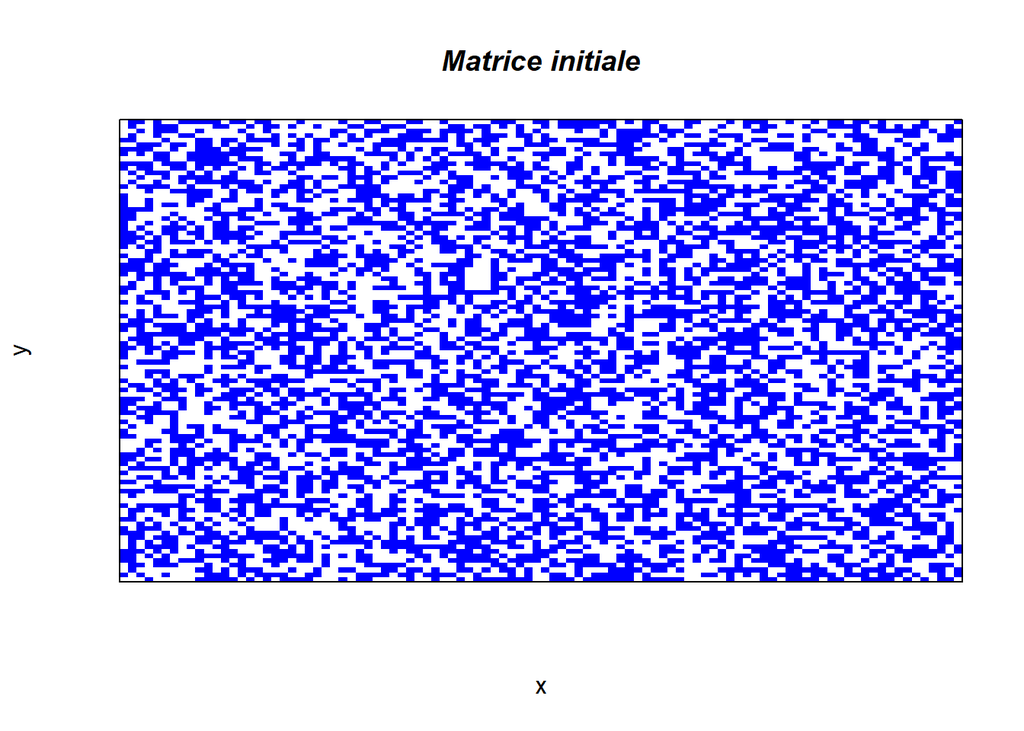

```r
n=100
s=matrix(1-2*rbinom(n*n,1,0.5),n,n)

displayMatrix=function(s,text){
  x= 10*(1:n)
  y= 10*(1:n)
  #image(x, y, s, col = terrain.colors(100), axes = FALSE)
  image(x, y, s, col = c("white","blue"), axes = FALSE)
  contour(x, y, s, levels = seq(90, 200, by = 5),
          add = TRUE, col = "gray")
  #axis(1, at = seq(100, 800, by = 100))
  #axis(2, at = seq(100, 600, by = 100))
  box()
  title(main = text, font.main = 4)
}
displayMatrix(s,"Matrice initiale")
```

Apres 100 iterations de Gibbs-Sampler:

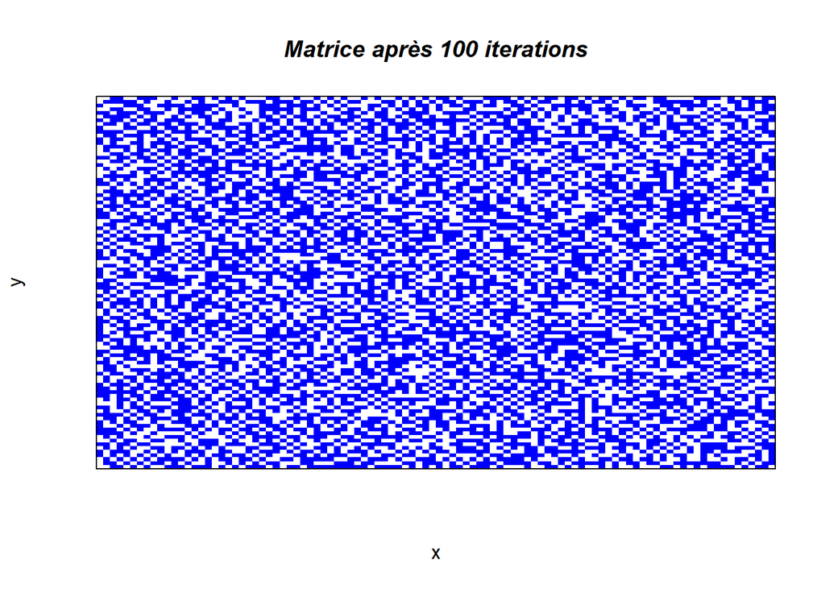

```r
H=0.5
J=0.5
nIterations=100
for (nIt in 1:nIterations) {
  for (i in 1:n){
    for (j in 1:n) {
      #First compute sum of neighbors
      sumN=0
      if (i > 1) {
        sumN=sumN+s[i-1,j]
      }
      if (i < n) {
        sumN=sumN+s[i+1,j]
      }
      if (j > 1) {
        sumN=sumN+s[i,j-1]
      }
      if (j < n) {
        sumN=sumN+s[i,j+1]
      }
    #print(i)
    #print(j)
    #print(sumN)
      prob=exp(-(H+(J*sumN)*(s[i,j]+1)))/(1+exp(-2*(H+(J*sumN))))
      #print(prob)
      #s[i,j]=1
      if (runif(1)>prob) #Switch the value
      {
        s[i,j]= -1*s[i,j]
      }
      #print(p)
    }
  }
}

displayMatrix(s,"Matrice après 100 iterations")
```

Apres 500 iterations supplémentaires de Gibbs-Sampler:

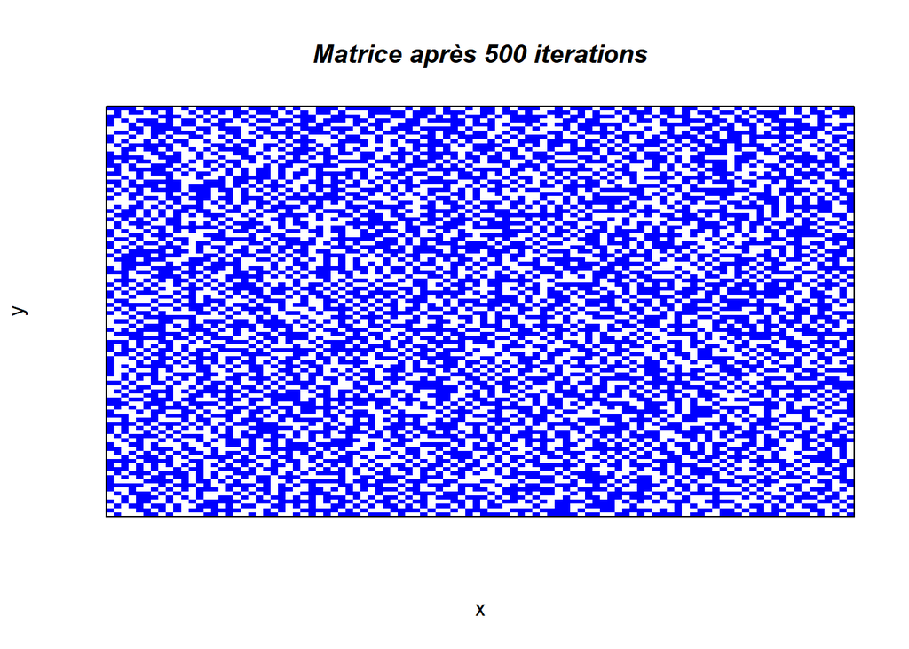

```r
nIterations=500
for (nIt in 1:nIterations) {
  for (i in 1:n){
    for (j in 1:n) {
      #First compute sum of neighbors
      sumN=0
      if (i > 1) {
        sumN=sumN+s[i-1,j]
      }
      if (i < n) {
        sumN=sumN+s[i+1,j]
      }
      if (j > 1) {
        sumN=sumN+s[i,j-1]
      }
      if (j < n) {
        sumN=sumN+s[i,j+1]
      }
    #print(i)
    #print(j)
    #print(sumN)
      prob=exp(-(H+(J*sumN)*(s[i,j]+1)))/(1+exp(-2*(H+(J*sumN))))
      #print(prob)
      #s[i,j]=1
      if (runif(1)>prob) #Switch the value
      {
        s[i,j]= -1*s[i,j]
      }
      #print(p)
    }
  }
}

displayMatrix(s,"Matrice après 500 iterations")
```